# **Chapter 03 條件式**

```python
x = 5
if x < 10:
    print('Smaller')
if x > 20:
    print('Bigger')
print('Finish')
```

```
Smaller
Finish
```

## **條件式步驟**

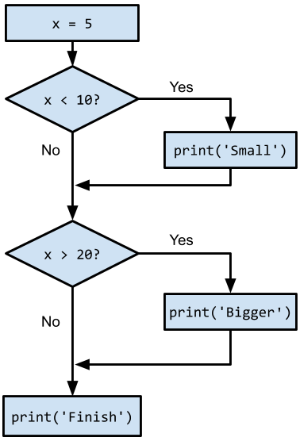

## **比較運算子 Comparison Operators**

- 布林(Boolean)表達式問一個問題並產生是或否結果，我們用它來控製程序流程
- 使用布林表達式的比較結果為True / False 或 Yes / No
- 比較運算子會查看變數內容，但不更改變數的內容
- <
  - 小於
- <=
  - 小於等於
- ==
  - 等於
- >=
  - 大於等於
- >
  - 大於
- !=
  - 不等於

```python
x = 5
if x == 5:
  print('等於 5')
if x > 4:
  print('大於 4')
if x >= 5:
  print('大於等於 5')
if x < 6:
  print('小於 6')
if x <= 5:
  print('小於等於 5')
if x != 6:
  print('不等於 6')
```

```
等於 5
大於 4
大於等於 5
小於 6
小於等於 5
不等於 6
```

## **單向條件式 One-way Decision**

```python
x = 5
print('Before 5')
if x == 5:
  print('Is 5')
  print('Is Still 5')
  print('Third 5')
print('Afterward 5')
print('Before 6')
if x == 6:
  print('Is 6')
  print('Is Still 6')
  print('Third 6')
print('Afterward 6')
```

```
Before 5
Is 5
Is Still 5
Third 5
Afterward 5
Before 6
Afterward 6
```

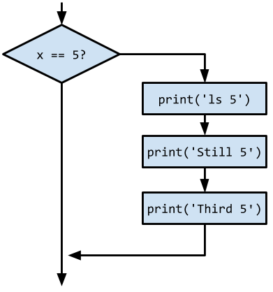

## **縮排 Indentation**

- 在if或for之後增加縮排
- 保持縮排指明if或for程式碼區塊的範圍（哪些行受if / for影響）
- 將縮排減少到if語句或for語句的級別，以指示區塊(Block)的結尾
- 空行(Blank Lines)將被忽略，不會影響縮排
- 註釋(Comments)不論縮排或是不縮排都是被忽略

### 警告：不要使用Tab縮排

- 使用Tab縮排與使用多個空白鍵進行縮排外表看起來相同
- 但混用在同一個程式碼中時就會出現「indentation errors」
- 在Colab中編輯程式碼時會自動調整

```python
x = 5
if x > 2 :
    # 增加縮排，表示是if要執行的內容
    print('Bigger than 2')
    print('Still bigger')

# 跳出if，文字要縮排回跟if相同的位置
print('Done with 2')

# 這是沒有縮排
for i in range(5) :
    # 這是第一層縮排
    print(i)
    if i > 2 :
        # 這是第二層縮排
        print('Bigger than 2')
    # 恢復到第一層縮排
    print('Done with i', i)
# 恢復到沒有縮排
print('All Done')
```

[output not shown]

## **練習**

- 寫一個程式，設定一個變數bmi，值自己指定
- 如果bmi大於24.9，就印出「不健康」

## **巢狀條件式 Nested Decision**

```python
x = 42
# 條件式一
if x > 1:
  print('More than one')
  # 條件式中的條件式
  if x < 100:
    print('Less than 100')
print('All Done')
```

```
More than one
Less than 100
All Done
```

[figure not shown]

## **雙向條件式 Two-way Decision**

- 有時我們想在判斷式為true的情況下做一件事，而在false的情況下做另一件事
- 就像路上的叉子-我們**只能選擇其中一條路徑**，但不能全部選擇

```python
x = 4

if x > 2 :
    print('Bigger')
else :
    print('Smaller')

print('All done')
```

```
Bigger
All done
```

### 視覺化呈現條件式

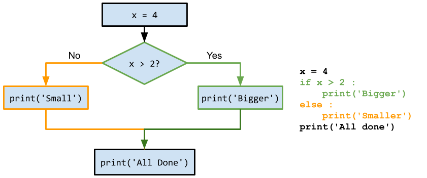

## **多重條件式 Multi-way**

### 多重條件式 Multi-way (1)

- 條件式可以是if - elif - else

```python
# 用以下數字代換，來看看條件式路徑
# x = 0
# x = 5
x = 20
if x < 2:
    print('small')
elif x < 10:
    print('Medium')
else:
    print('LARGE')
print('All Done')
```

[output not shown]

[figure not shown]

### 多重條件式 Multi-way (2)

- 條件式可以只有if - elif，沒有else

```python
# 以下條件式，沒有else，也是可以的
x = 5
if x < 2:
    print('small')
elif x < 10:
    print('Medium')
print('All Done')
```

```
Medium
All Done
```

### 多重條件式 Multi-way (3)

- 條件式可以是 if - elif - elif - elif - ... - elif - else。非常多個elif也沒關係

```python
# 用以下數字代換，來看看條件式路徑
# x = 0
# x = 20
x = 400
if x < 2:
    print('small')
elif x < 10:
    print('Medium')
elif x < 20:
    print('Big')
elif x < 40:
    print('Large')
elif x < 100:
    print('Huge')
else:
    print('Ginormous')
```

```
Ginormous
```

### 多重條件式難題 (1)

- 下列程式碼，不管x的值是多少，永遠都不會印出來？

  ```
  if x < 2:
    print('Below 2')
  elif x >= 2:
    print('Two or more')
  else:
    print('Something else')
  ```

```python
x = 2
# x = ?
if x < 2:
    print('Below 2')
elif x >= 2:
    print('Two or more')
else:
    # this line will never be executed
    print('Something else')
```

```
Two or more
```

### 多重條件式難題 (2)

- 下列程式碼，不管x的值是多少，永遠都不會印出來？

  ```
  if x < 2:
    print('Below 2')
  elif x < 20:
    print('Below 20')
  elif x < 10:
    print('Below 10')
  else:
    print('Something else')
  ```

```python
x = 6
if x < 2:
    print('Below 2')
elif x < 20: # Trigger first
    print('Below 20')
elif x < 10: # never run
    print('Below 10')
else:
    print('Something else')
```

```
Below 20
```

## **練習**

- 寫個程式，請用戶輸入得分
  - 分數要落在0.0 ~ 1.0之間，當用戶輸入超過範圍，印出"輸入錯誤"
  - 如果輸入的分數在0.0 ~ 1.0之間，照以下內容印出他得到的評比
    - >= 0.9 A
    - >= 0.8 B
    - >= 0.7 C
    - >= 0.6 D
    - < 0.6 F
- 最後程式寫完，可以用0.85來做測試，結果應該是B

## **try / except 結構**

- 您用try和except包圍代碼的危險部分
- 如果在try中的程式碼是沒問題的 - except的部分則會忽略
- 如果在try中的程式碼出錯了 - 程式就會跳向except的部分

```python
astr = 'Hello Bob'
istr = int(astr)
print('First', istr)
astr = '123'
istr = int(astr)
print('Second', istr)
```

```
---------------------------------------------------------------------------
ValueError                                Traceback (most recent call last)
<ipython-input-6-a96d2ddd189b> in <module>()
      1 astr = 'Hello Bob'
----> 2 istr = int(astr)
      3 print('First', istr)
      4 astr = '123'
      5 istr = int(astr)

ValueError: invalid literal for int() with base 10: 'Hello Bob'
```

### Traceback

- 程式出錯，讓Python無法正常執行下去，整個程式就停止在錯誤的那一行

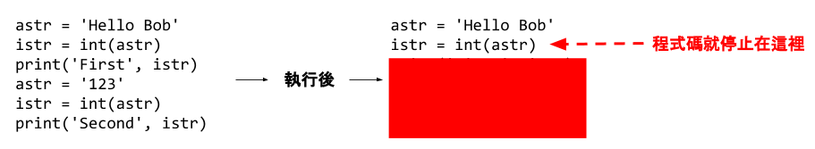

### 程式補上try/except

```python
astr = 'Hello Bob'
# 當第一段轉換失敗時，程式碼就會跳到except
# 且程式碼正常繼續執行
try:
    istr = int(astr)
except:
    istr = -1

print('First', istr)

astr = '123'
# 當第二段轉換成功。程式並不會進入except
# 程式碼正常繼續執行
try:
    istr = int(astr)
except:
    istr = -1

print('Second', istr)
```

```
First -1
Second 123
```

### try/except示意圖

- 放在try之中的程式碼盡量少，因為一旦出錯接下來的程式碼都不會執行了

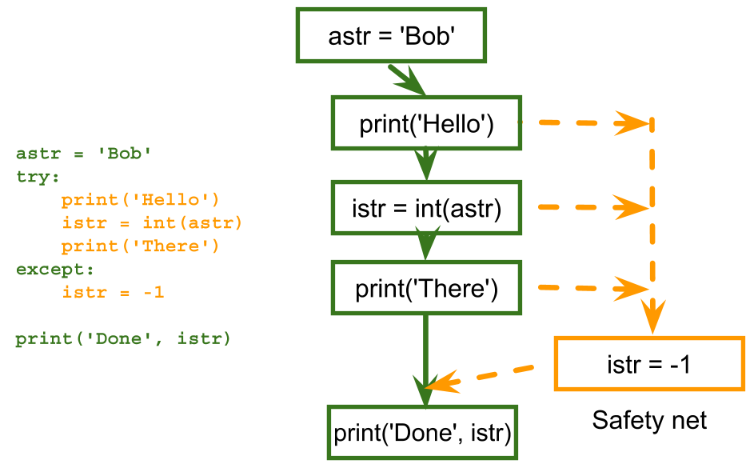

### try/except的範例

- 結合之前講的input()

```python
# 試著輸入數字，也輸入一般文字
rawstr = input('Enter a number:')
try:
    ival = int(rawstr)
except:
    ival = -1

if ival > 0:
    print('Nice work')
else:
    print('Not a number')
```

## **總結複習**

- 比較運算子 Comparison Operators
  - ==
  - <=
  - >=
  - >
  - <
  - !=
- 縮排 indentation
- 單向條件式
- 巢狀條件式
- 雙向條件式
  - if: and else:
- 多重條件式
  - if elif else
- try/except結構

## **作業**

- 針對上一次的作業，在程式碼中加上try/except，以免用戶輸入不能轉換為數字的內容
  - 若用戶輸入的非數字，則跳出「請輸入數字」
- 最後以輸入兩次來做測試
  - 第一次
    - 工作小時：20、工作時薪：nine
    - 輸出結果應該跳出，請輸入數字
  - 第二次
    - 工作小時：forty
    - 輸出結果應該跳出，請輸入數字

# Acknowledgements / Contributions

Python For Everyone

- These slides are Copyright 2010- Charles R. Severance (www.dr-chuck.com) of the University of Michigan School of Information and made available under a Creative Commons Attribution 4.0 License. Please maintain this last slide in all copies of the document to comply with the attribution requirements of the license. If you make a change, feel free to add your name and organization to the list of contributors on this page as you republish the materials.
- Initial Development: Charles Severance, University of Michigan School of Information